# White Wine Exploration by Mohammad Albloushi

### Introduction

In this project i’m going to explore this data set using data analysis techniques, with an objective of finding Which chemical properties influence the quality of white wines.

This tidy data set contains 4,898 white wines with 13 variables on quantifying the chemical properties of each wine. At least 3 wine experts rated the quality of each wine, providing a rating between 0 (very bad) and 10 (very excellent).

Read this [text file](https://s3.amazonaws.com/udacity-hosted-downloads/ud651/wineQualityInfo.txt) which describes the variables and how the data was collected.

### Summary of the data:

```
## [1] 4898   13
```

There are **4898** observations and **13** variables.

```
##  [1] "X"                    "fixed.acidity"        "volatile.acidity"
##  [4] "citric.acid"          "residual.sugar"       "chlorides"
##  [7] "free.sulfur.dioxide"  "total.sulfur.dioxide" "density"
## [10] "pH"                   "sulphates"            "alcohol"
## [13] "quality"
```

These are the variable names.

```
## 'data.frame':    4898 obs. of  13 variables:
##  $ X                   : int  1 2 3 4 5 6 7 8 9 10 ...
##  $ fixed.acidity       : num  7 6.3 8.1 7.2 7.2 8.1 6.2 7 6.3 8.1 ...
##  $ volatile.acidity    : num  0.27 0.3 0.28 0.23 0.23 0.28 0.32 0.27 0.3 0.22 ...
##  $ citric.acid         : num  0.36 0.34 0.4 0.32 0.32 0.4 0.16 0.36 0.34 0.43 ...
##  $ residual.sugar      : num  20.7 1.6 6.9 8.5 8.5 6.9 7 20.7 1.6 1.5 ...
##  $ chlorides           : num  0.045 0.049 0.05 0.058 0.058 0.05 0.045 0.045 0.049 0.044 ...
##  $ free.sulfur.dioxide : num  45 14 30 47 47 30 30 45 14 28 ...
##  $ total.sulfur.dioxide: num  170 132 97 186 186 97 136 170 132 129 ...
##  $ density             : num  1.001 0.994 0.995 0.996 0.996 ...
##  $ pH                  : num  3 3.3 3.26 3.19 3.19 3.26 3.18 3 3.3 3.22 ...
##  $ sulphates           : num  0.45 0.49 0.44 0.4 0.4 0.44 0.47 0.45 0.49 0.45 ...
##  $ alcohol             : num  8.8 9.5 10.1 9.9 9.9 10.1 9.6 8.8 9.5 11 ...
##  $ quality             : int  6 6 6 6 6 6 6 6 6 6 ...
```

All of the variables are numerical variables except for **X** And **Quality** which are integer,The **X** Variable is just an index variable for each observation.

```
##        X        fixed.acidity    volatile.acidity  citric.acid
##  Min.   :   1   Min.   : 3.800   Min.   :0.0800   Min.   :0.0000
##  1st Qu.:1225   1st Qu.: 6.300   1st Qu.:0.2100   1st Qu.:0.2700
##  Median :2450   Median : 6.800   Median :0.2600   Median :0.3200
##  Mean   :2450   Mean   : 6.855   Mean   :0.2782   Mean   :0.3342
##  3rd Qu.:3674   3rd Qu.: 7.300   3rd Qu.:0.3200   3rd Qu.:0.3900
##  Max.   :4898   Max.   :14.200   Max.   :1.1000   Max.   :1.6600
##  residual.sugar     chlorides       free.sulfur.dioxide
##  Min.   : 0.600   Min.   :0.00900   Min.   :  2.00
##  1st Qu.: 1.700   1st Qu.:0.03600   1st Qu.: 23.00
##  Median : 5.200   Median :0.04300   Median : 34.00
##  Mean   : 6.391   Mean   :0.04577   Mean   : 35.31
##  3rd Qu.: 9.900   3rd Qu.:0.05000   3rd Qu.: 46.00
##  Max.   :65.800   Max.   :0.34600   Max.   :289.00
##  total.sulfur.dioxide    density             pH          sulphates
##  Min.   :  9.0        Min.   :0.9871   Min.   :2.720   Min.   :0.2200
##  1st Qu.:108.0        1st Qu.:0.9917   1st Qu.:3.090   1st Qu.:0.4100
##  Median :134.0        Median :0.9937   Median :3.180   Median :0.4700
##  Mean   :138.4        Mean   :0.9940   Mean   :3.188   Mean   :0.4898
##  3rd Qu.:167.0        3rd Qu.:0.9961   3rd Qu.:3.280   3rd Qu.:0.5500
##  Max.   :440.0        Max.   :1.0390   Max.   :3.820   Max.   :1.0800
##     alcohol         quality
##  Min.   : 8.00   Min.   :3.000
##  1st Qu.: 9.50   1st Qu.:5.000
##  Median :10.40   Median :6.000
##  Mean   :10.51   Mean   :5.878
##  3rd Qu.:11.40   3rd Qu.:6.000
##  Max.   :14.20   Max.   :9.000
```

### Creating a new variable

I’m going to add a factor variable called **Rating** which will help us tell which wine got **High**, **Average** or **Low** ratings, All of our variables are either numerical or integer, This is going to be helpful for investigating further in our analysis. I’m going to make a bucket for quality scores as:

- 0 to 4 : **Bad**
- 5 to 6 : **Average**
- 7 to 10 : **Good**

```r
winedata$rating <- cut(winedata$quality, # Creating a bucket from the quality variable.
                       c(0, 4, 6, 10),
                       labels = c('Bad', 'Average', 'Good'))
```

```
##     Bad Average    Good
##     183    3655    1060
```

Most of the wine has an **Average** rating, and there’s more **Good** wine than **Bad** wine.

# Univariate Plots Section

### Quality

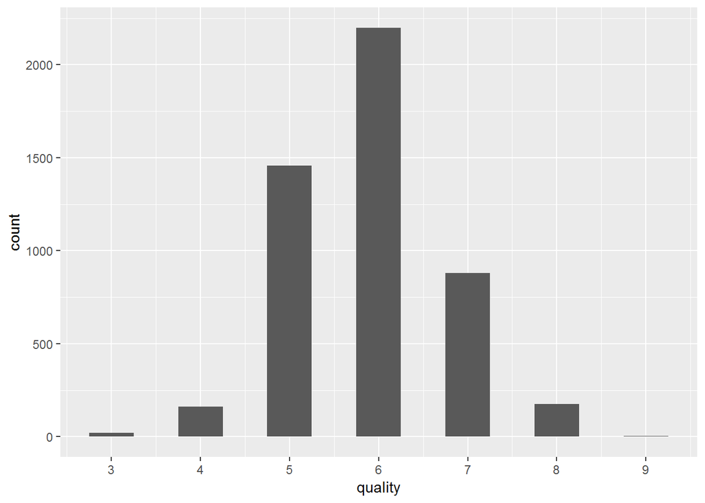

```
##    Min. 1st Qu.  Median    Mean 3rd Qu.    Max.
##   3.000   5.000   6.000   5.878   6.000   9.000
```

Most of the values lie between **3** and **9** with a peek at **6**, The distribution seems to be normal.

### Fixed Acidity

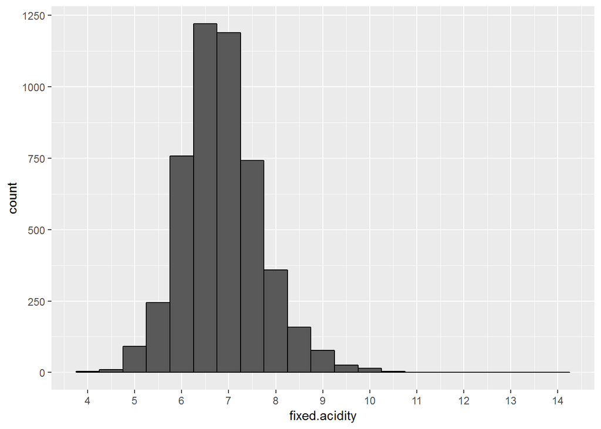

```
##    Min. 1st Qu.  Median    Mean 3rd Qu.    Max.
##   3.800   6.300   6.800   6.855   7.300  14.200
```

The values in **Fixed Acidity** lie between **3.8** and **14.20**, This histogram show’s that there is only a few values less than **4** and more than **10** so i’m going to limit my values in the next histogram.

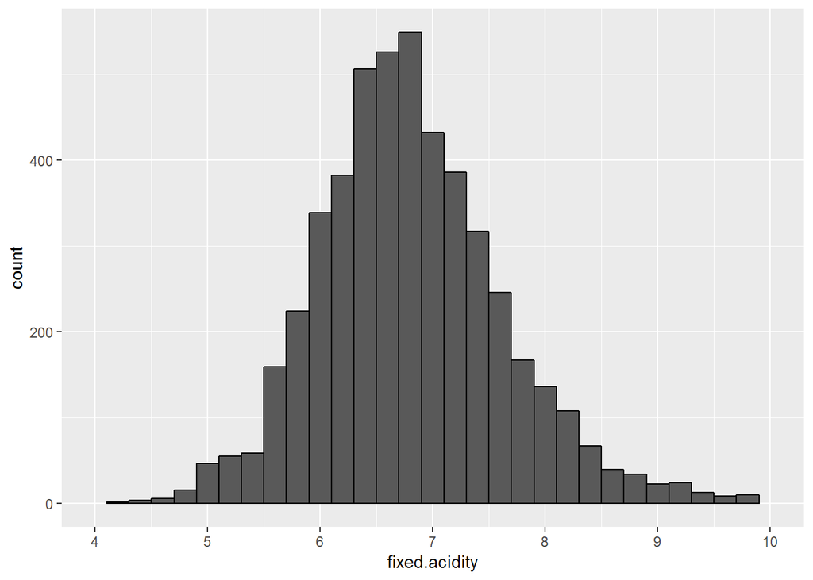

The distribution is normal now and most of the fixed acidity is between **6** to **8**.

### Volatile Acidity

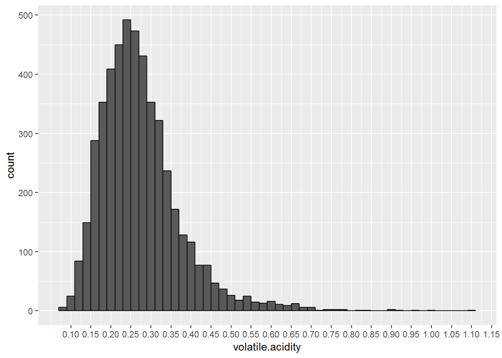

```
##    Min. 1st Qu.  Median    Mean 3rd Qu.    Max.
##  0.0800  0.2100  0.2600  0.2782  0.3200  1.1000
```

The values in this histogram lie between **0.0800** and **1.1**, From this histogram i can see that there are few values as well under **0.1** and more than **0.65** so i’m going to adjust it.

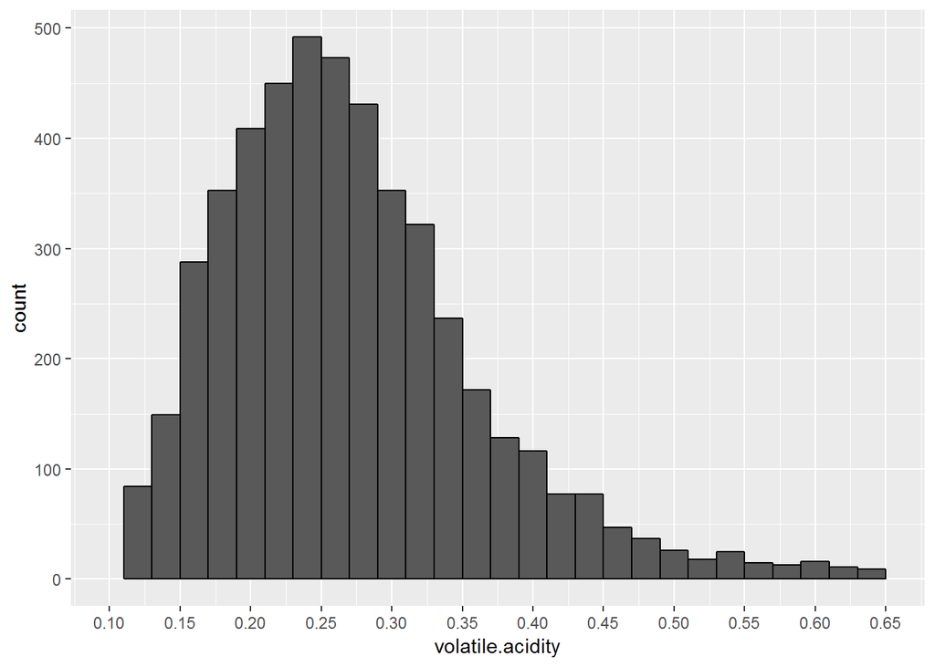

This distribution is slightly positively skewed as we can see, Most of the volatile acidity is between **0.2** and **0.3**.

### Citric Acid

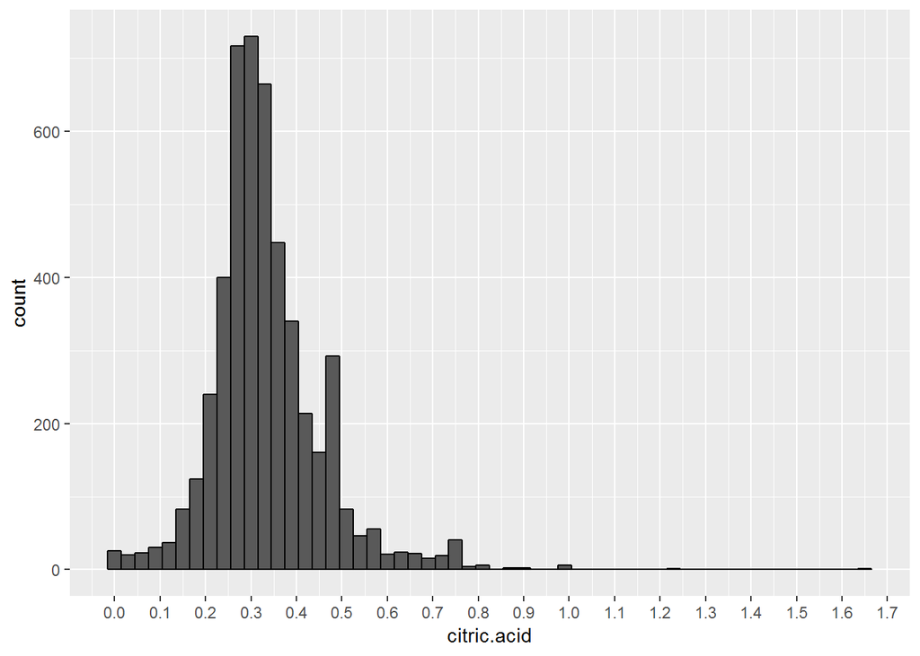

```
##    Min. 1st Qu.  Median    Mean 3rd Qu.    Max.
##  0.0000  0.2700  0.3200  0.3342  0.3900  1.6600
```

The values lie between **0** and **1.6600** which and from the histogram we can see that there seems to be values around 0, We can see values after **0.75** with less count, Which makes our histogram long tailed so i will limit it in the next histogram.

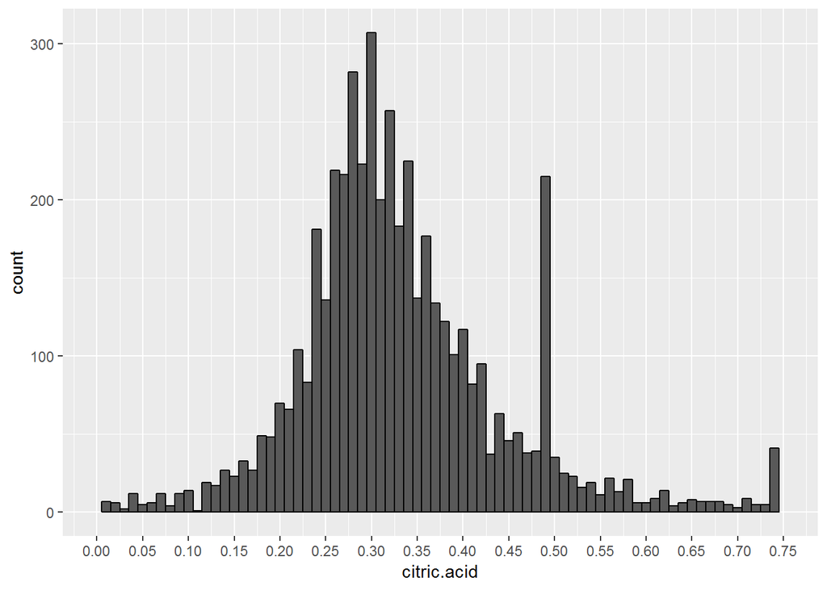

Now the distribution looks normal and we can see the distribution in a better way, Most of the values lies between **0.20** and **0.50** and there is a big bar around **0.48**.

### Residual Sugar

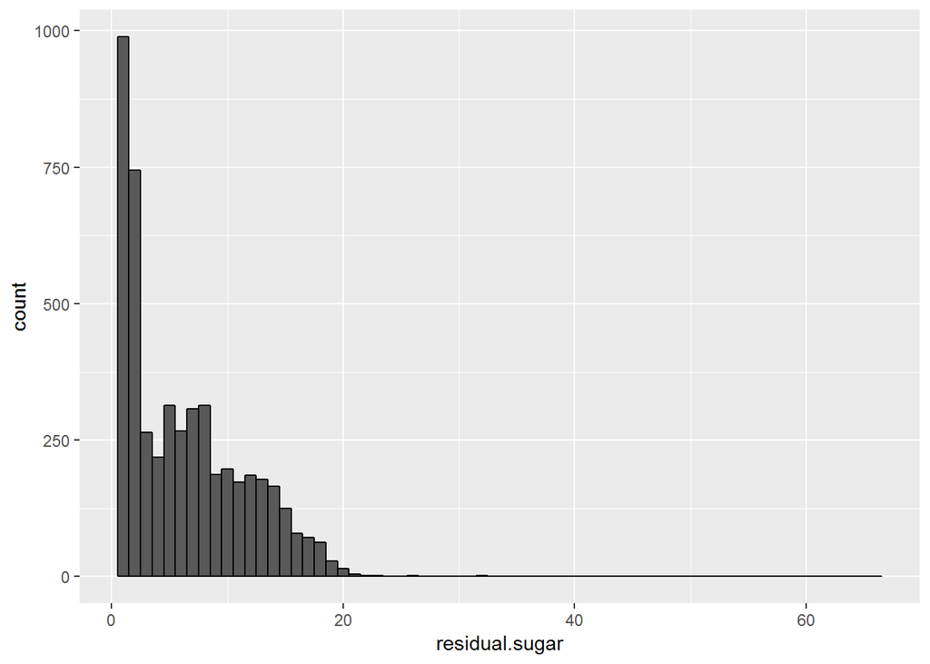

```
##    Min. 1st Qu.  Median    Mean 3rd Qu.    Max.
##   0.600   1.700   5.200   6.391   9.900  65.800
```

75% of our values are less than **9.900** and the max is **65.800**, I can’t really understand a lot in this histogram so i’m going to use **log 10** to understand the long tail distribution.

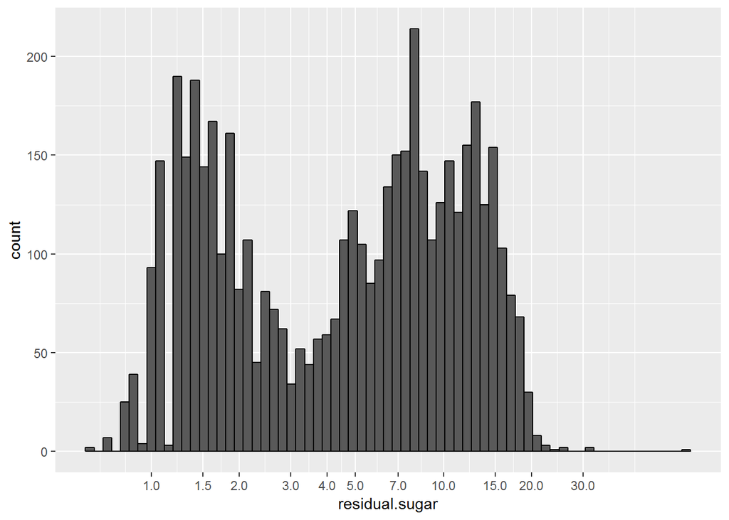

Using **log10** i can see a bimodal distribution, there’s multiple peaks in the histogram, One of them is between **1** and **2.5**, There a small peeks between **1** and **1.5** with low count surrounded by high peeks.

### Chlorides

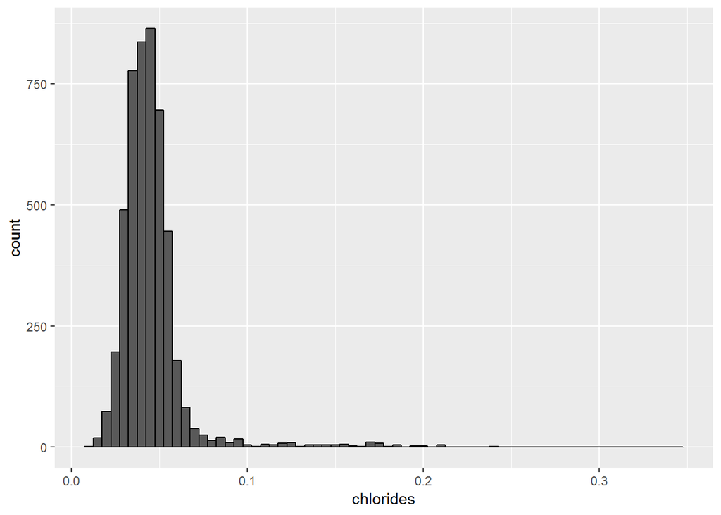

```
##    Min. 1st Qu.  Median    Mean 3rd Qu.    Max.
## 0.00900 0.03600 0.04300 0.04577 0.05000 0.34600
```

The range for **Chlorides** is between **0.00900** and **0.34600**, Just like **Residual Sugar** i’m going to use **log 10** the better understand the histogram.

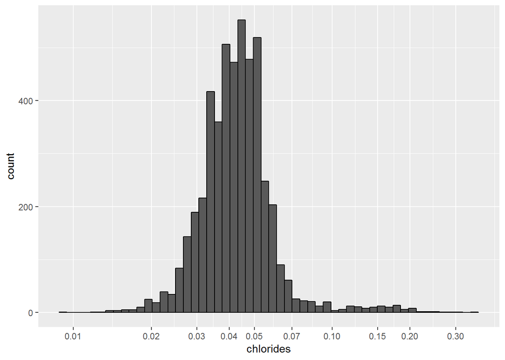

When I used **log 10** I can see that most values lies between **0.03** and **0.06**, And the distribution look’s normal.

### Free Sulfur Dioxide

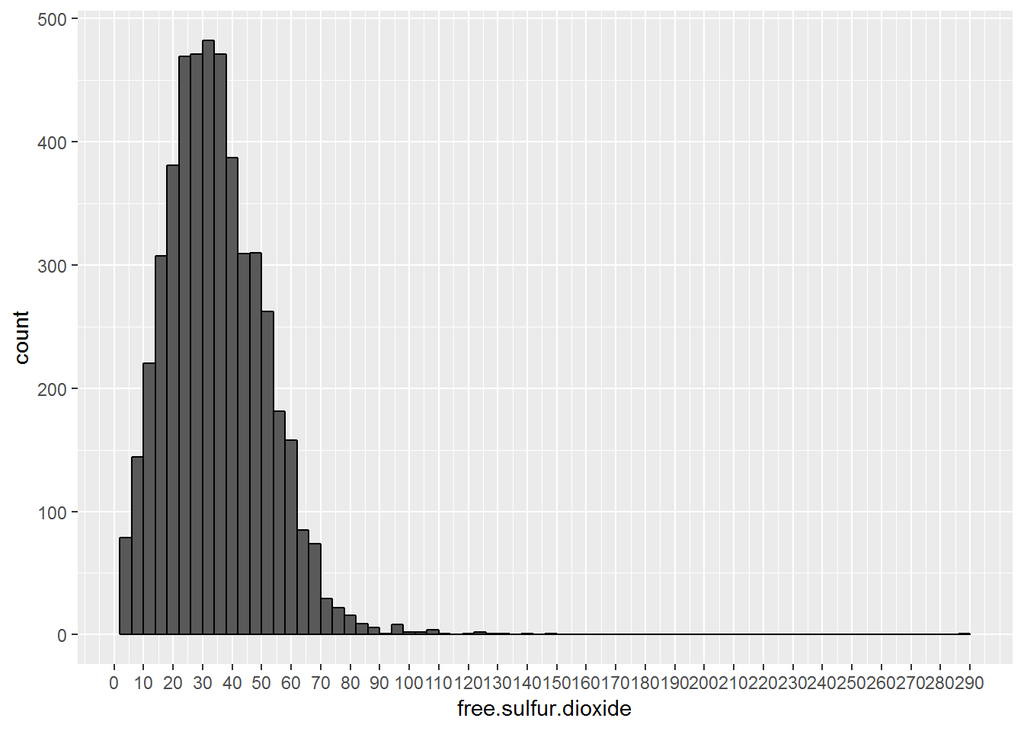

```
##    Min. 1st Qu.  Median    Mean 3rd Qu.    Max.
##    2.00   23.00   34.00   35.31   46.00  289.00
```

From looking at this histogram I can detect outliers , the median for **Free Sulfur Dioxide** is **34** and The maximum is **289**, I’m going to limit my values in the next histogram.

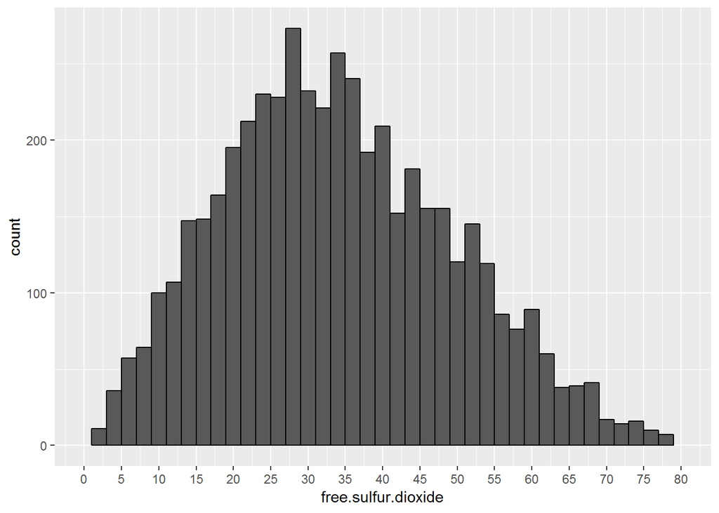

The distribution looks almost like a perfect normal distribution now, The highest peak happened around **27** and **28**.

### Total Sulfure Dioxide

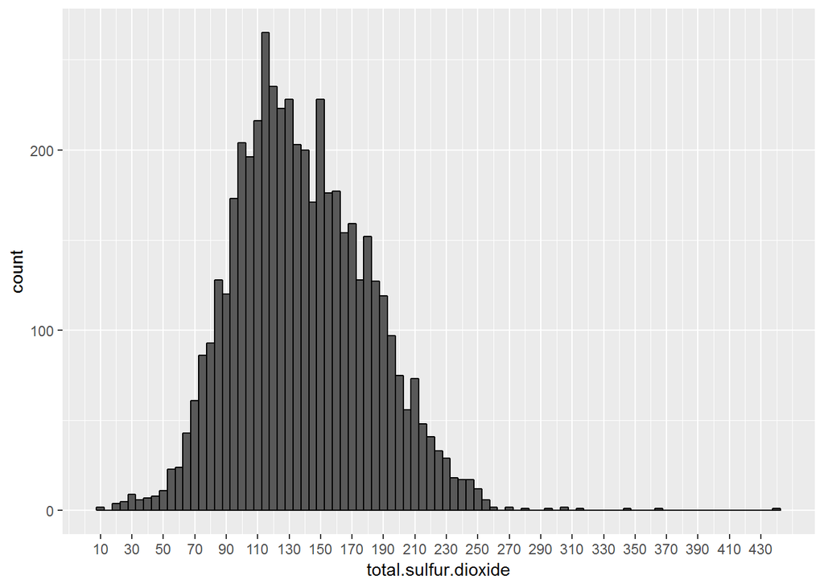

```
##    Min. 1st Qu.  Median    Mean 3rd Qu.    Max.
##     9.0   108.0   134.0   138.4   167.0   440.0
```

I can detect a few outliers in these values since 75% of our data is under **167** and our maximum is **440**, I’m going to limit our values to better understand the histogram.

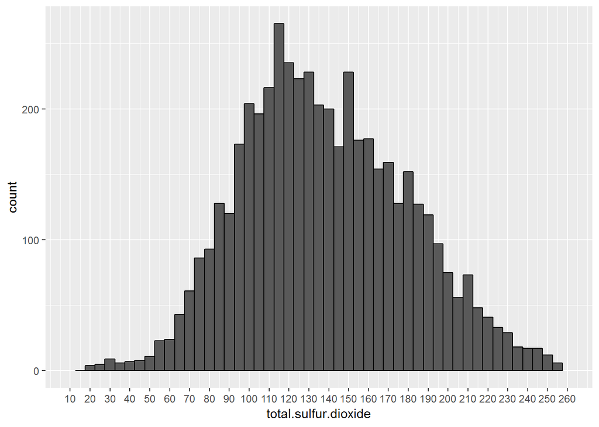

The distribution look’s normal with the highest peak from **95** to **160**.

### Density

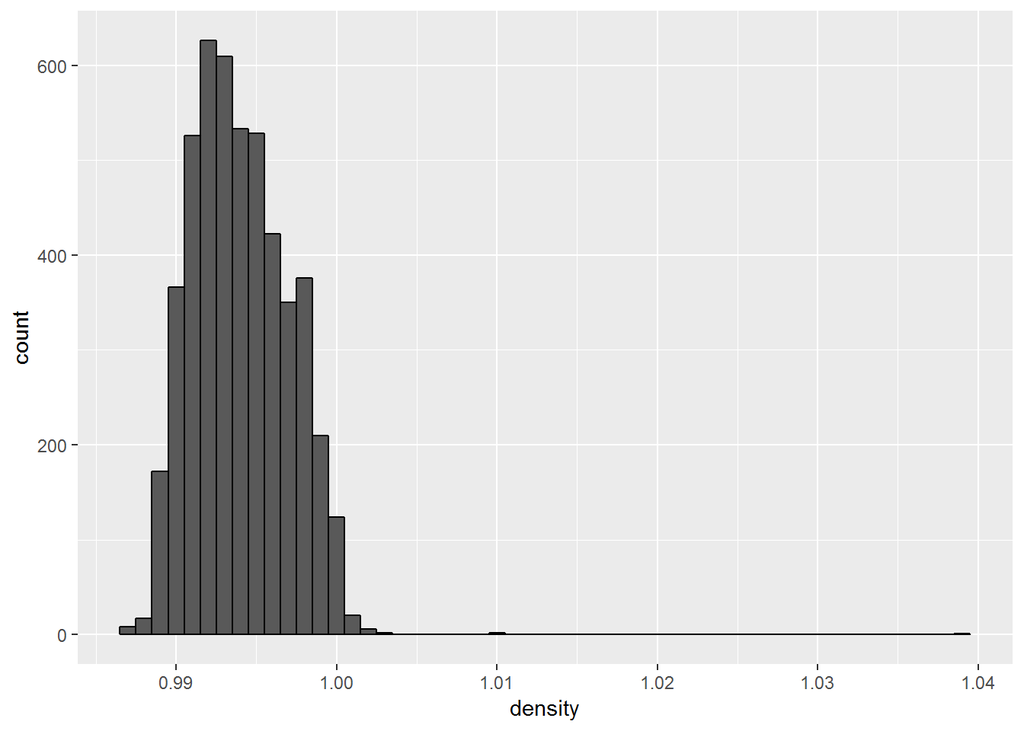

```
##    Min. 1st Qu.  Median    Mean 3rd Qu.    Max.
##  0.9871  0.9917  0.9937  0.9940  0.9961  1.0390
```

This distribution is hard to work with because it has such low and close numbers, i can tell by just looking at the histogram that most data lie somewhere between **0.98** and **1** so i’m going to limit my values to understand and see the values.

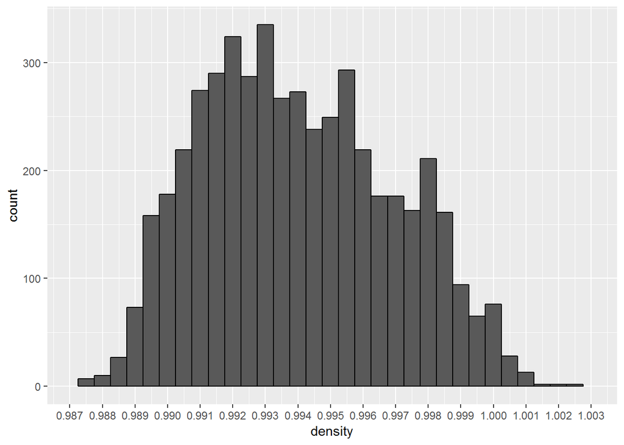

### pH

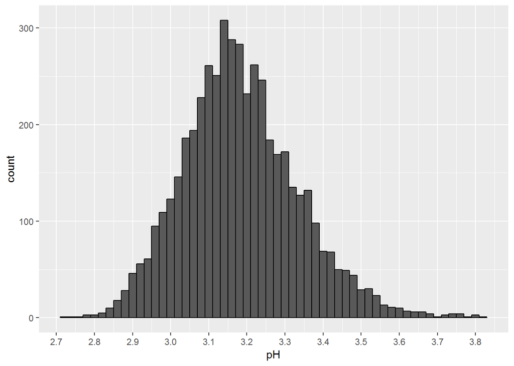

```
##    Min. 1st Qu.  Median    Mean 3rd Qu.    Max.
##   2.720   3.090   3.180   3.188   3.280   3.820
```

This distribution look normal with most values lies between **3.1** and **3.3**.

### Sulphates

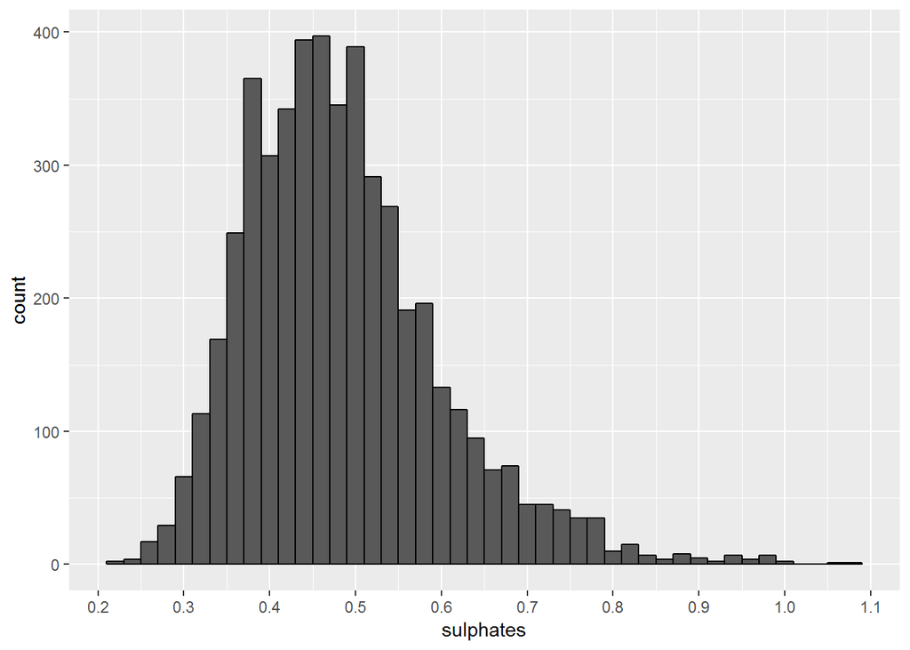

```
##    Min. 1st Qu.  Median    Mean 3rd Qu.    Max.
##  0.2200  0.4100  0.4700  0.4898  0.5500  1.0800
```

**Sulphates** histogram look’s slightly positively skewed with the highest peak around **0.4** and **0.5**.

### Alcohol

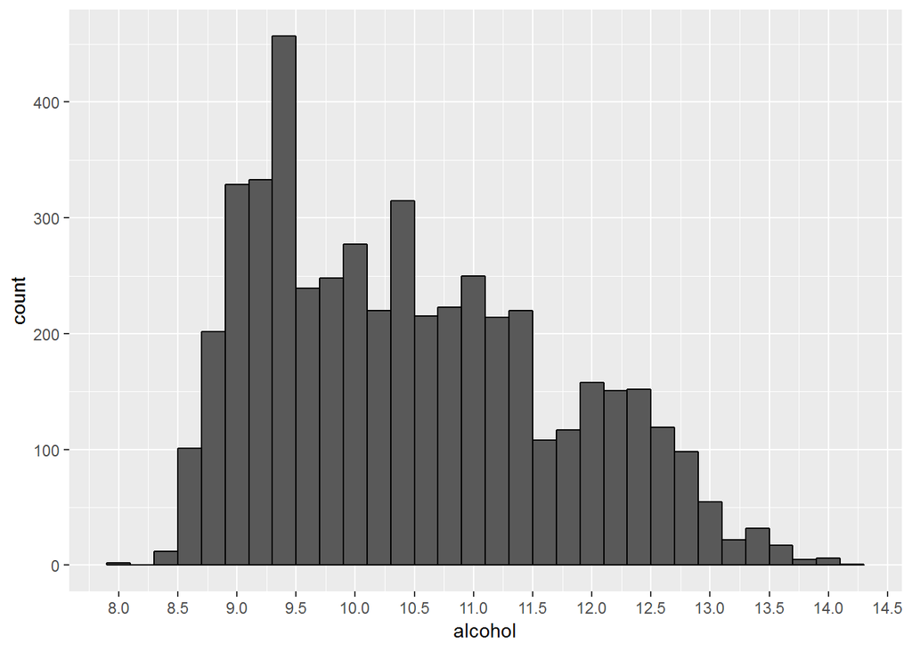

```
##    Min. 1st Qu.  Median    Mean 3rd Qu.    Max.
##    8.00    9.50   10.40   10.51   11.40   14.20
```

The distribution is positively skewed and the highest peak happened around **9.4**.

# Univariate Analysis

### What is the structure of your dataset?

In this data set there are **12** variables (Without the X Variable) and **4898** observations, I Also created a new variable called **Rating** which classify the quality of the wine (13 Variables), All of our data is numerical except for **Quality** and **Rating**.

### What is/are the main feature(s) of interest in your dataset?

My main feature is **Quality**, I’m trying to detect which chemical properties influence the **Quality** of white wines.

### What other features in the dataset do you think will help support your investigation into your feature(s) of interest?

It’s hard to guess which feature influence the quality of wine because most of the plots have normal distribution, but if i have to guess it’s going to be **Residual Sugar** and **Alcohol**.

### Did you create any new variables from existing variables in the dataset?

Yes i created a new variable called **Rating** which basiclly classify the **Quality** of wines to **Bad**, **Average** and **Good**.

### Of the features you investigated, were there any unusual distributions? Did you perform any operations on the data to tidy, adjust, or change the form of the data? If so, why did you do this?

I did multiple operation to adjust my histograms, one of them is **Residual Sugar** it had a positive skew but after i performed log 10 on the scale it gave me a bimodel distribution.

# Bivariate Plots Section

I’m going to use a correlation matrix to get the strongest correlations for **Quality** and other strong correlations.

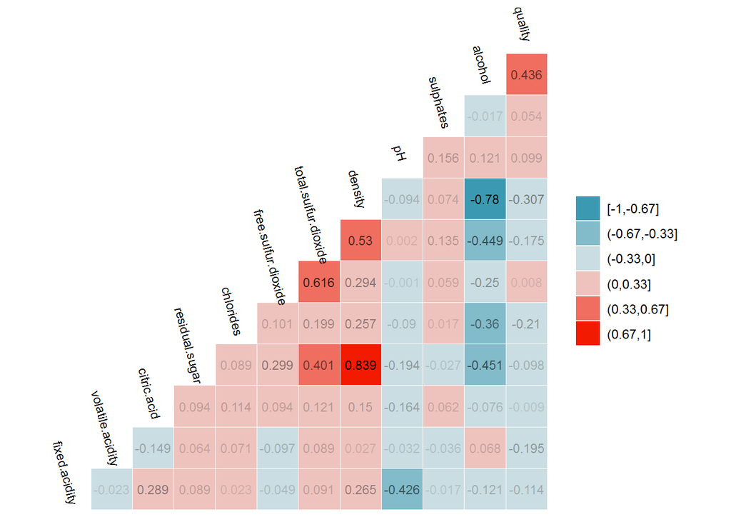

This correlation matrix shows us that the strongest correlation for quality is:

- **Quality x Alcohol (0.436)**
- **Quality x Density (-0.307)**
- **Quality x Chlorides (-0.21)**

We can also observe that the top 5 strongest correlations are :

- **Density x Residual Sugar (0.839)**
- **Density x Alcohol (-0.78)**
- **Total Sulfur Dioxide x Free Sulfur Dioxide (0.616)**
- **Density x Total Sulfur Dioxide (0.53)**
- **Alcohol x Residual Sugar (-0.451)**

Since I’m interested in which properties affect the **Quality** of wine i’m going to quickly box plot each chemical properties into a box plot and limit 1% from it to observe any patterns in the box plot that might be interesting to look at.

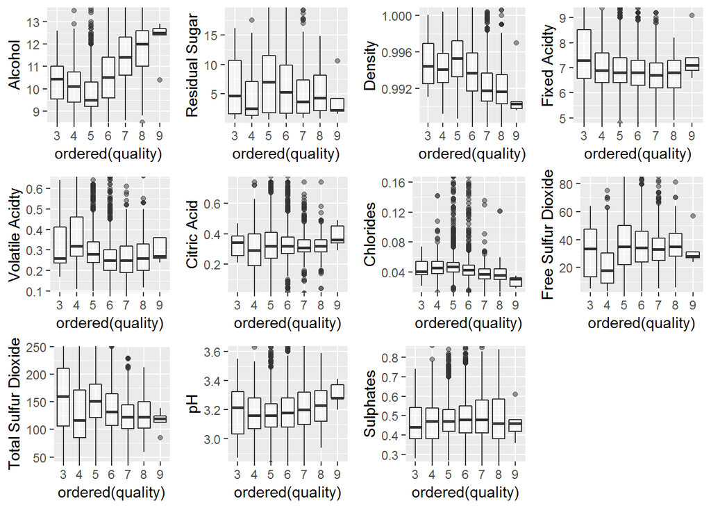

The relationships worth looking into is :

- **Quality x Alcohol**
- **Quality x Density**
- **Quality x Chlorides**
- **Quality x pH**
- **Quality x Total Sulfur Dioxide**
- **Quality x Volatile Acidity**

Let’s look closely into these Relationships.

### Quality x Alcohol

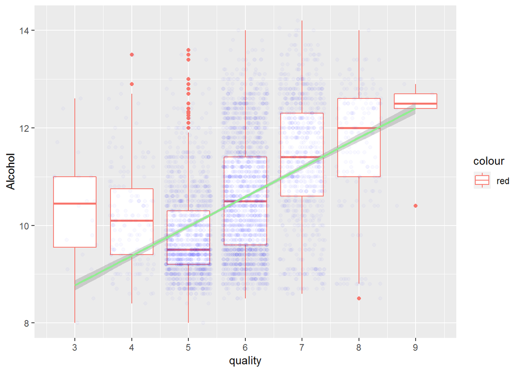

```
## ordered(winedata$quality): 3
##    Min. 1st Qu.  Median    Mean 3rd Qu.    Max.
##    8.00    9.55   10.45   10.35   11.00   12.60
## --------------------------------------------------------
## ordered(winedata$quality): 4
##    Min. 1st Qu.  Median    Mean 3rd Qu.    Max.
##    8.40    9.40   10.10   10.15   10.75   13.50
## --------------------------------------------------------
## ordered(winedata$quality): 5
##    Min. 1st Qu.  Median    Mean 3rd Qu.    Max.
##   8.000   9.200   9.500   9.809  10.300  13.600
## --------------------------------------------------------
## ordered(winedata$quality): 6
##    Min. 1st Qu.  Median    Mean 3rd Qu.    Max.
##    8.50    9.60   10.50   10.58   11.40   14.00
## --------------------------------------------------------
## ordered(winedata$quality): 7
##    Min. 1st Qu.  Median    Mean 3rd Qu.    Max.
##    8.60   10.60   11.40   11.37   12.30   14.20
## --------------------------------------------------------
## ordered(winedata$quality): 8
##    Min. 1st Qu.  Median    Mean 3rd Qu.    Max.
##    8.50   11.00   12.00   11.64   12.60   14.00
## --------------------------------------------------------
## ordered(winedata$quality): 9
##    Min. 1st Qu.  Median    Mean 3rd Qu.    Max.
##   10.40   12.40   12.50   12.18   12.70   12.90
```

We know that **Alcohol** has the strongest correlation with **Quality**, And it’s showing in the plot that alcohol has in fact effect on the quality of the wine,The median for **Quality** of 4 is **10.10** and the median for **Quality** of 8 is **12**, We can see after quality 5 as the **Alcohol** increases the **Quality** of the wine increases.

### Quality x Density

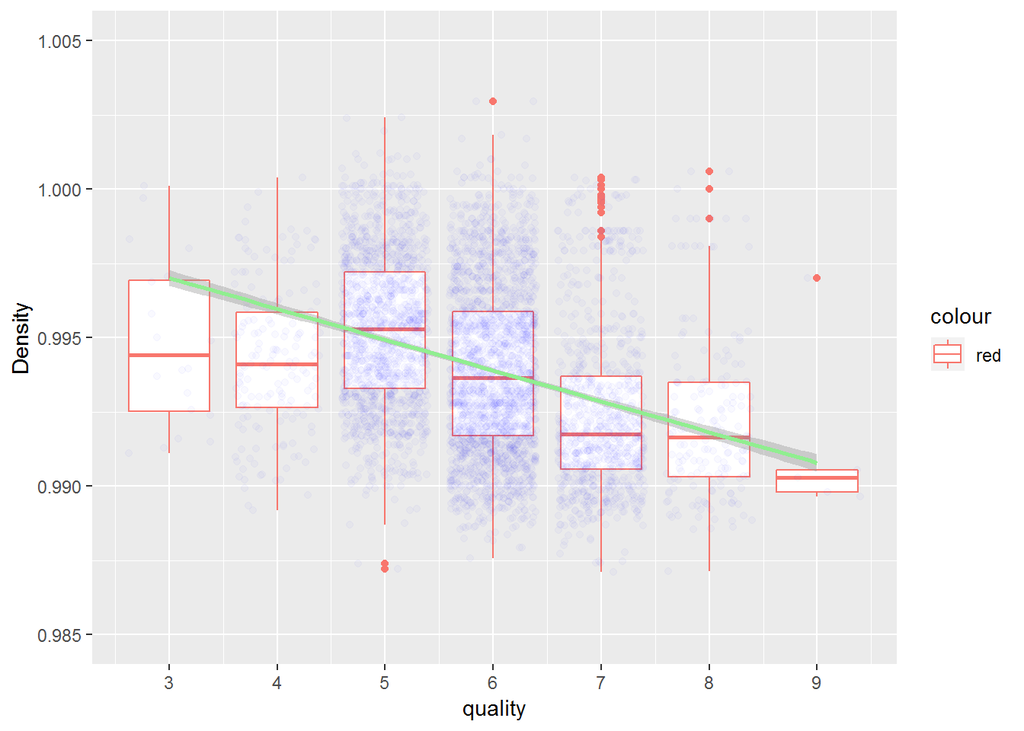

```
## ordered(winedata$quality): 3
##    Min. 1st Qu.  Median    Mean 3rd Qu.    Max.
##  0.9911  0.9925  0.9944  0.9949  0.9969  1.0001
## --------------------------------------------------------
## ordered(winedata$quality): 4
##    Min. 1st Qu.  Median    Mean 3rd Qu.    Max.
##  0.9892  0.9926  0.9941  0.9943  0.9958  1.0004
## --------------------------------------------------------
## ordered(winedata$quality): 5
##    Min. 1st Qu.  Median    Mean 3rd Qu.    Max.
##  0.9872  0.9933  0.9953  0.9953  0.9972  1.0024
## --------------------------------------------------------
## ordered(winedata$quality): 6
##    Min. 1st Qu.  Median    Mean 3rd Qu.    Max.
##  0.9876  0.9917  0.9937  0.9940  0.9959  1.0390
## --------------------------------------------------------
## ordered(winedata$quality): 7
##    Min. 1st Qu.  Median    Mean 3rd Qu.    Max.
##  0.9871  0.9906  0.9918  0.9925  0.9937  1.0004
## --------------------------------------------------------
## ordered(winedata$quality): 8
##    Min. 1st Qu.  Median    Mean 3rd Qu.    Max.
##  0.9871  0.9903  0.9916  0.9922  0.9935  1.0006
## --------------------------------------------------------
## ordered(winedata$quality): 9
##    Min. 1st Qu.  Median    Mean 3rd Qu.    Max.
##  0.9897  0.9898  0.9903  0.9915  0.9906  0.9970
```

**Quality** and **Density** have a negative relationship as shown in the plot, if we don’t include **Quality** 3 and 4 we can see that as the density decrease the rating increase.

### Quality x Chlorides

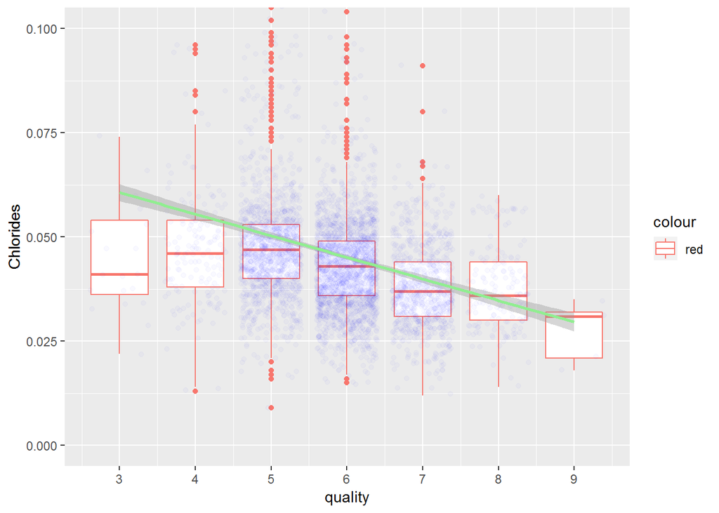

```
## ordered(winedata$quality): 3
##    Min. 1st Qu.  Median    Mean 3rd Qu.    Max.
## 0.02200 0.03625 0.04100 0.05430 0.05400 0.24400
## --------------------------------------------------------
## ordered(winedata$quality): 4
##    Min. 1st Qu.  Median    Mean 3rd Qu.    Max.
##  0.0130  0.0380  0.0460  0.0501  0.0540  0.2900
## --------------------------------------------------------
## ordered(winedata$quality): 5
##    Min. 1st Qu.  Median    Mean 3rd Qu.    Max.
## 0.00900 0.04000 0.04700 0.05155 0.05300 0.34600
## --------------------------------------------------------
## ordered(winedata$quality): 6
##    Min. 1st Qu.  Median    Mean 3rd Qu.    Max.
## 0.01500 0.03600 0.04300 0.04522 0.04900 0.25500
## --------------------------------------------------------
## ordered(winedata$quality): 7
##    Min. 1st Qu.  Median    Mean 3rd Qu.    Max.
## 0.01200 0.03100 0.03700 0.03819 0.04400 0.13500
## --------------------------------------------------------
## ordered(winedata$quality): 8
##    Min. 1st Qu.  Median    Mean 3rd Qu.    Max.
## 0.01400 0.03000 0.03600 0.03831 0.04400 0.12100
## --------------------------------------------------------
## ordered(winedata$quality): 9
##    Min. 1st Qu.  Median    Mean 3rd Qu.    Max.
##  0.0180  0.0210  0.0310  0.0274  0.0320  0.0350
```

We can see that we have a negative relationship between **Quality** and **Chlorides**, if we don’t include **Quality** of 3 we can observe as the **Chlorides** decrease the quality increase.

### Quality x pH

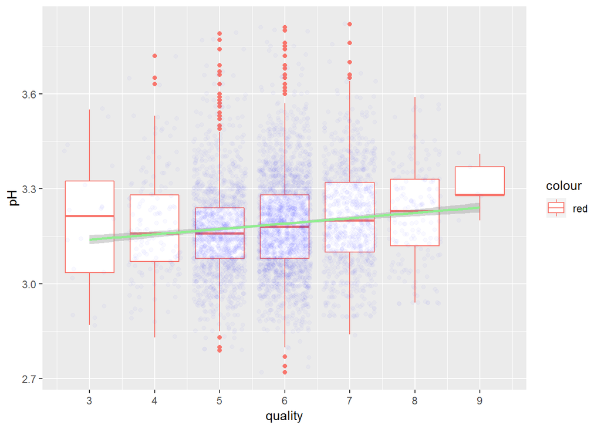

```
## ordered(winedata$quality): 3
##    Min. 1st Qu.  Median    Mean 3rd Qu.    Max.
##   2.870   3.035   3.215   3.188   3.325   3.550
## --------------------------------------------------------
## ordered(winedata$quality): 4
##    Min. 1st Qu.  Median    Mean 3rd Qu.    Max.
##   2.830   3.070   3.160   3.183   3.280   3.720
## --------------------------------------------------------
## ordered(winedata$quality): 5
##    Min. 1st Qu.  Median    Mean 3rd Qu.    Max.
##   2.790   3.080   3.160   3.169   3.240   3.790
## --------------------------------------------------------
## ordered(winedata$quality): 6
##    Min. 1st Qu.  Median    Mean 3rd Qu.    Max.
##   2.720   3.080   3.180   3.189   3.280   3.810
## --------------------------------------------------------
## ordered(winedata$quality): 7
##    Min. 1st Qu.  Median    Mean 3rd Qu.    Max.
##   2.840   3.100   3.200   3.214   3.320   3.820
## --------------------------------------------------------
## ordered(winedata$quality): 8
##    Min. 1st Qu.  Median    Mean 3rd Qu.    Max.
##   2.940   3.120   3.230   3.219   3.330   3.590
## --------------------------------------------------------
## ordered(winedata$quality): 9
##    Min. 1st Qu.  Median    Mean 3rd Qu.    Max.
##   3.200   3.280   3.280   3.308   3.370   3.410
```

Here we have a positive correlation, we can see the median for **Quality** increases as the **pH** increase.

### Quality x Total Sulfur Dioxide

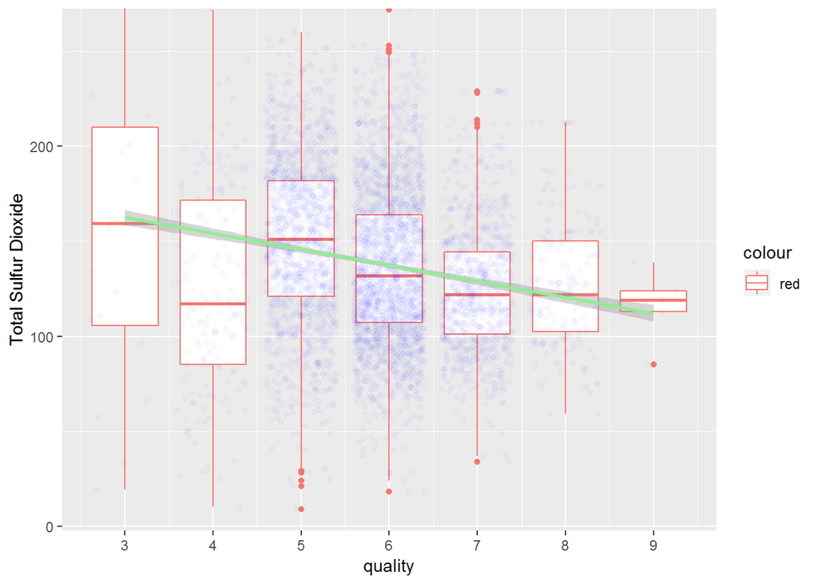

```
## ordered(winedata$quality): 3
##    Min. 1st Qu.  Median    Mean 3rd Qu.    Max.
##    19.0   105.8   159.5   170.6   210.0   440.0
## --------------------------------------------------------
## ordered(winedata$quality): 4
##    Min. 1st Qu.  Median    Mean 3rd Qu.    Max.
##    10.0    85.0   117.0   125.3   171.5   272.0
## --------------------------------------------------------
## ordered(winedata$quality): 5
##    Min. 1st Qu.  Median    Mean 3rd Qu.    Max.
##     9.0   121.0   151.0   150.9   182.0   344.0
## --------------------------------------------------------
## ordered(winedata$quality): 6
##    Min. 1st Qu.  Median    Mean 3rd Qu.    Max.
##    18.0   107.2   132.0   137.0   164.0   294.0
## --------------------------------------------------------
## ordered(winedata$quality): 7
##    Min. 1st Qu.  Median    Mean 3rd Qu.    Max.
##    34.0   101.0   122.0   125.1   144.2   229.0
## --------------------------------------------------------
## ordered(winedata$quality): 8
##    Min. 1st Qu.  Median    Mean 3rd Qu.    Max.
##    59.0   102.5   122.0   126.2   150.0   212.5
## --------------------------------------------------------
## ordered(winedata$quality): 9
##    Min. 1st Qu.  Median    Mean 3rd Qu.    Max.
##      85     113     119     116     124     139
```

### Quality x Volatile Acidity

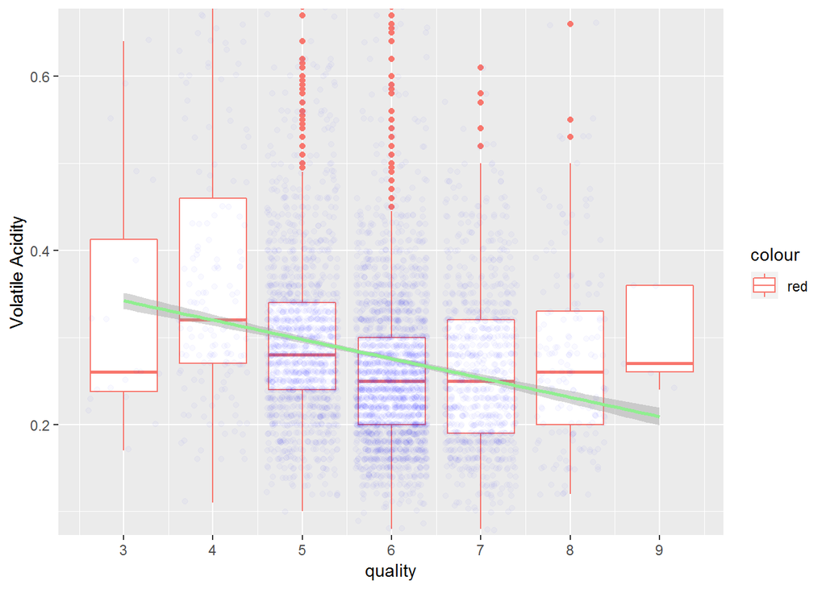

```
## ordered(winedata$quality): 3
##    Min. 1st Qu.  Median    Mean 3rd Qu.    Max.
##  0.1700  0.2375  0.2600  0.3332  0.4125  0.6400
## --------------------------------------------------------
## ordered(winedata$quality): 4
##    Min. 1st Qu.  Median    Mean 3rd Qu.    Max.
##  0.1100  0.2700  0.3200  0.3812  0.4600  1.1000
## --------------------------------------------------------
## ordered(winedata$quality): 5
##    Min. 1st Qu.  Median    Mean 3rd Qu.    Max.
##   0.100   0.240   0.280   0.302   0.340   0.905
## --------------------------------------------------------
## ordered(winedata$quality): 6
##    Min. 1st Qu.  Median    Mean 3rd Qu.    Max.
##  0.0800  0.2000  0.2500  0.2606  0.3000  0.9650
## --------------------------------------------------------
## ordered(winedata$quality): 7
##    Min. 1st Qu.  Median    Mean 3rd Qu.    Max.
##  0.0800  0.1900  0.2500  0.2628  0.3200  0.7600
## --------------------------------------------------------
## ordered(winedata$quality): 8
##    Min. 1st Qu.  Median    Mean 3rd Qu.    Max.
##  0.1200  0.2000  0.2600  0.2774  0.3300  0.6600
## --------------------------------------------------------
## ordered(winedata$quality): 9
##    Min. 1st Qu.  Median    Mean 3rd Qu.    Max.
##   0.240   0.260   0.270   0.298   0.360   0.360
```

Now let’s look at the strongest correlations other than **Quality**.

### Residual Sugar x Density

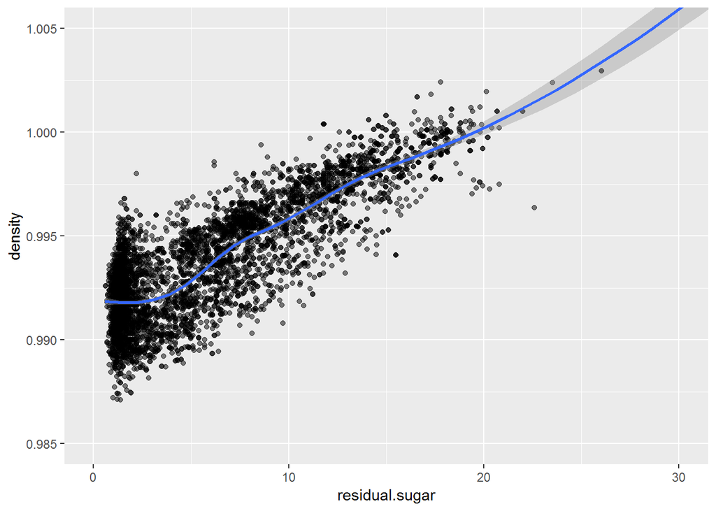

### Alcohol x Density

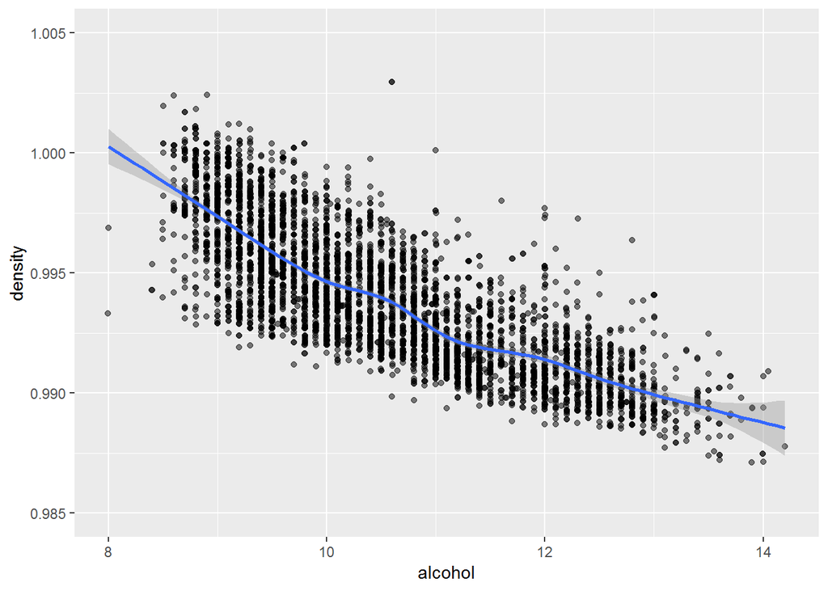

Here we have also a strong relationship, But it’s negative, it’s almost the opposite of **Residual sugar**, But with better spread in our plot, we can observe as the **Alcohol** increase the **Density** will decrease.

### Total Sulfur Dioxide x Free Sulfur Dioxide

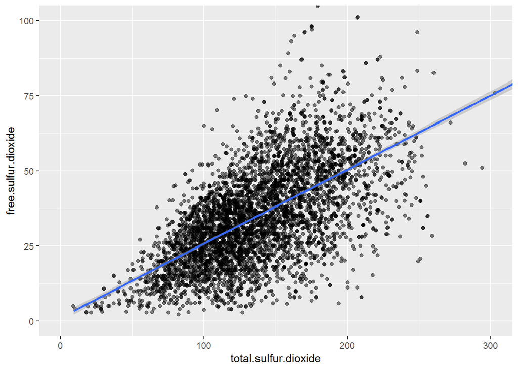

Here we have a positive relationship, But with a much wider spread in our data.